Note

Go to the end to download the full example code. or to run this example in your browser via JupyterLite or Binder

# Outlier detection with Local Outlier Factor (LOF)

The Local Outlier Factor (LOF) algorithm is an unsupervised anomaly detection method which computes the local density deviation of a given data point with respect to its neighbors. It considers as outliers the samples that have a substantially lower density than their neighbors. This example shows how to use LOF for outlier detection which is the default use case of this estimator in scikit-learn. Note that when LOF is used for outlier detection it has no `predict`, `decision_function` and `score_samples` methods. See the User Guide for details on the difference between outlier detection and novelty detection and how to use LOF for novelty detection.

The number of neighbors considered (parameter `n_neighbors`) is typically set 1) greater than the minimum number of samples a cluster has to contain, so that other samples can be local outliers relative to this cluster, and 2) smaller than the maximum number of close by samples that can potentially be local outliers. In practice, such information is generally not available, and taking `n_neighbors=20` appears to work well in general.

```
# Authors: The scikit-learn developers
# SPDX-License-Identifier: BSD-3-Clause
```

## Generate data with outliers

```
import numpy as np

np.random.seed(42)

X_inliers = 0.3 * np.random.randn(100, 2)
X_inliers = np.r_[X_inliers + 2, X_inliers - 2]
X_outliers = np.random.uniform(low=-4, high=4, size=(20, 2))
X = np.r_[X_inliers, X_outliers]

n_outliers = len(X_outliers)
ground_truth = np.ones(len(X), dtype=int)
ground_truth[-n_outliers:] = -1
```

## Fit the model for outlier detection (default)

Use `fit_predict` to compute the predicted labels of the training samples (when LOF is used for outlier detection, the estimator has no `predict`, `decision_function` and `score_samples` methods).

```
from sklearn.neighbors import LocalOutlierFactor

clf = LocalOutlierFactor(n_neighbors=20, contamination=0.1)
y_pred = clf.fit_predict(X)
n_errors = (y_pred != ground_truth).sum()
X_scores = clf.negative_outlier_factor_
```

## Plot results

```
import matplotlib.pyplot as plt
from matplotlib.legend_handler import HandlerPathCollection


def update_legend_marker_size(handle, orig):
    "Customize size of the legend marker"
    handle.update_from(orig)
    handle.set_sizes([20])


plt.scatter(X[:, 0], X[:, 1], color="k", s=3.0, label="Data points")
# plot circles with radius proportional to the outlier scores
radius = (X_scores.max() - X_scores) / (X_scores.max() - X_scores.min())
scatter = plt.scatter(
    X[:, 0],
    X[:, 1],
    s=1000 * radius,
    edgecolors="r",
    facecolors="none",
    label="Outlier scores",
)
plt.axis("tight")
plt.xlim((-5, 5))
plt.ylim((-5, 5))
plt.xlabel("prediction errors: %d" % (n_errors))
plt.legend(
    handler_map={scatter: HandlerPathCollection(update_func=update_legend_marker_size)}
)
plt.title("Local Outlier Factor (LOF)")
plt.show()
```

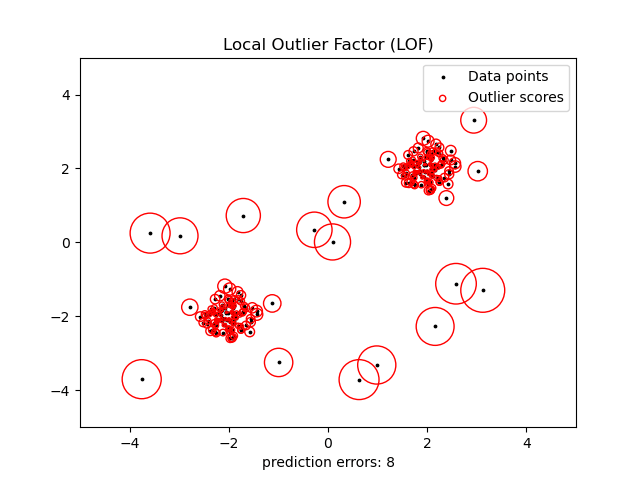

**Total running time of the script:** (0 minutes 0.085 seconds)

[figure not shown]

[`Download Jupyter notebook: plot_lof_outlier_detection.ipynb`](https://scikit-learn.org/1.6/_downloads/a91fcd567e6bc2540b34f44d599d3531/plot_lof_outlier_detection.ipynb)

[`Download Python source code: plot_lof_outlier_detection.py`](https://scikit-learn.org/1.6/_downloads/06d58c7fb0650278c0e3ea127bff7167/plot_lof_outlier_detection.py)

[`Download zipped: plot_lof_outlier_detection.zip`](https://scikit-learn.org/1.6/_downloads/80f1673b50d88ee3f77b8540882e9964/plot_lof_outlier_detection.zip)

#### Related examples

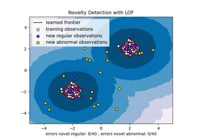

Novelty detection with Local Outlier Factor (LOF)

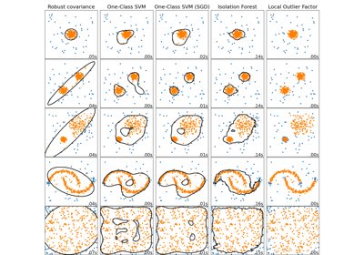

Comparing anomaly detection algorithms for outlier detection on toy datasets

[figure not shown]

Evaluation of outlier detection estimators

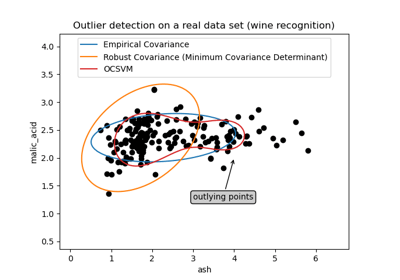

Outlier detection on a real data set

© 2007–2025 The scikit-learn developers  
Licensed under the 3-clause BSD License.  
https://scikit-learn.org/1.6/auto_examples/neighbors/plot_lof_outlier_detection.html